# [Sensor Data Harversting for CBM+] 수집 데이터 확인

- **(수집일자)** 2023년 9월 27일 ~ 29일 (3일간)
- **(수집대상)** 스마트폰 내장 센서 데이터

  > **`센서종류`** 가속도, 자이로, 지자기, 조도 및 기압 센서 등
- **(수집방법)** 차량 거치(대시보드 상단 무선 충전기 또는 기어박스 상부 수납 공간 활용)

  > **`활용기기`** 삼성 갤럭시 s23U

  > **`활용App`** vieyra software 사의 Physics toolbox sensor suite Pro

## 1. 환경 설정

```python
import sys
sys.version
```

```
'3.10.12 | packaged by Anaconda, Inc. | (main, Jul  5 2023, 19:01:18) [MSC v.1916 64 bit (AMD64)]'
```

```python
import numpy as np
import pandas as pd
import matplotlib.pyplot as plt
import seaborn as sns


import os
os.listdir()
```

```
['.ipynb_checkpoints',
 '1st_day_course.html',
 '2nd_day_course.html',
 'autoviz_First_Day_png',
 'autoviz_Second_Day_png',
 'autoviz_whole_png',
 'data',
 'data_acq-Copy1.ipynb',
 'data_acq.ipynb',
 'data_acq_autoviz.ipynb',
 'data_acq_test-Copy1.ipynb',
 'data_acq_test.ipynb',
 'data_pkl',
 'download_data',
 'hist_1st_day',
 'hist_html',
 'hist_src',
 'read_pickle.py',
 'requirement.txt',
 '데이터 수집 기록.xlsx']
```

```python
os.listdir('data_pkl')
```

```
['combined_df.pkl', 'combined_df2.pkl', 'whole_df.pkl']
```

### 피클 데이터 확인 및 전처리

- **(설명)** csv로 수집된 데이터들을 사전에 병합하여 pkl 파일로 저장함 -> pkl 데이터를 로드함

  > combined_df.pkl은 1일차에 수집한 총 5코스에 대한 병합 데이터프레임 (1구간 ~ 5구간)  
  > combined_df2.pkl은 2일차에 수집한 총 3코스에 대한 병합 데이터프레임 (6구간 ~ 8구간)
- **(수집일자)** 2023-09-28, 2023-09-29

  > 27일 데이터는 중간 중간 App이 백그라운드에서 sleep 모드가 되면서 많은 부분 수집이 누락됨
- **(수집구간)**
  > - (1구간) {course : A} 고성 문암리 -> 원통 우체국
  > - (2구간) {course : B} 원통 우체국 -> 양구 성곡재 인근
  > - (3구간) {course : C} 양구 성곡재 인근 -> 화천터미널
  > - (4구간) {course : D} 화천터미널 -> 47번 국도 합류점
  > - (5구간) {course : E} 47번 국도 합류점 -> 의정부
  > - (6구간) {course : F} 의정부 -> 춘천 위도 인근
  > - (7구간) {course : G} 춘천 -> 가평
  > - (8구간) {course : H} 가평 -> 의정부
- **(측정값)**
  > - 시간 (ms) 'time'
  > - 중력가속도(G) 'gFx', 'gFy', 'gFz'
  > - 선형가속도($m/s^2$): 'ax', 'ay', 'az'
  > - 자이로스코프(rad/s): 'wx', 'wy', 'wz'
  > - 기압(hpa) 'p'
  > - 자력($\mu T$) 'Bx', 'By', 'Bz'
  > - 광도(lux) 'I'
  > - 방위각($\degree$) 'Azimuth'
  > - 고도($\degree$) 'Pitch'
  > - 횡전($\degree$) 'Roll'
  > - 위도($\degree$) 'Latitude',
  > - 경도($\degree$) 'Longitude'
  > - 속도(m/s) 'Speed (m/s)'

```python
combined_df = pd.read_pickle('./data_pkl/combined_df.pkl')
combined_df2 = pd.read_pickle('./data_pkl/combined_df2.pkl')
```

```python
combined_df.info()
combined_df2.info()
```

```
<class 'pandas.core.frame.DataFrame'>
DatetimeIndex: 2505868 entries, 2023-09-28 07:21:27.939000 to 2023-09-28 12:37:39.324000
Data columns (total 21 columns):
 #   Column       Dtype
---  ------       -----
 0   gFx          float64
 1   gFy          float64
 2   gFz          float64
 3   ax           float64
 4   ay           float64
 5   az           float64
 6   wx           float64
 7   wy           float64
 8   wz           float64
 9   p            float64
```

[output cut: 41 more lines]

```python
combined_df.index
```

```
DatetimeIndex(['2023-09-28 07:21:27.939000', '2023-09-28 07:21:27.975000',
               '2023-09-28 07:21:27.985000', '2023-09-28 07:21:28.003000',
               '2023-09-28 07:21:28.005000', '2023-09-28 07:21:28.006000',
               '2023-09-28 07:21:28.007000', '2023-09-28 07:21:28.041000',
               '2023-09-28 07:21:28.045000', '2023-09-28 07:21:28.047000',
               ...
               '2023-09-28 12:37:39.275000', '2023-09-28 12:37:39.288000',
               '2023-09-28 12:37:39.298000', '2023-09-28 12:37:39.314000',
               '2023-09-28 12:37:39.317000', '2023-09-28 12:37:39.319000',
               '2023-09-28 12:37:39.320000', '2023-09-28 12:37:39.322000',
               '2023-09-28 12:37:39.323000', '2023-09-28 12:37:39.324000'],
              dtype='datetime64[ns]', name='time_ts', length=2505868, freq=None)
```

```python
combined_df2.index
```

```
DatetimeIndex(['2023-09-29 07:36:24.456000', '2023-09-29 07:36:24.476000',
               '2023-09-29 07:36:24.484000', '2023-09-29 07:36:24.502000',
               '2023-09-29 07:36:24.541000', '2023-09-29 07:36:24.550000',
               '2023-09-29 07:36:24.561000', '2023-09-29 07:36:24.562000',
               '2023-09-29 07:36:24.564000', '2023-09-29 07:36:24.601000',
               ...
               '2023-09-29 14:14:35.655000', '2023-09-29 14:14:35.666000',
               '2023-09-29 14:14:35.676000', '2023-09-29 14:14:35.678000',
               '2023-09-29 14:14:35.679000', '2023-09-29 14:14:35.689000',
               '2023-09-29 14:14:35.691000', '2023-09-29 14:14:35.695000',
               '2023-09-29 14:14:35.696000', '2023-09-29 14:14:35.698000'],
              dtype='datetime64[ns]', name='time_ts', length=2122834, freq=None)
```

```python
print(combined_df.columns)
print(combined_df2.columns)
```

```
Index(['gFx', 'gFy', 'gFz', 'ax', 'ay', 'az', 'wx', 'wy', 'wz', 'p', 'Bx',
       'By', 'Bz', 'I', 'Azimuth', 'Pitch', 'Roll', 'Latitude', 'Longitude',
       'Speed (m/s)', 'course'],
      dtype='object')
Index(['gFx', 'gFy', 'gFz', 'ax', 'ay', 'az', 'wx', 'wy', 'wz', 'p', 'Bx',
       'By', 'Bz', 'I', 'Azimuth', 'Pitch', 'Roll', 'Latitude', 'Longitude',
       'Speed (m/s)', 'course'],
      dtype='object')
```

```python
combined_df.describe().round(2)
```

|  | gFx | gFy | gFz | ax | ay | az | wx | wy | wz | p | Bx | By | Bz | I | Azimuth | Pitch | Roll | Latitude | Longitude | Speed (m/s) |
| --- | --- | --- | --- | --- | --- | --- | --- | --- | --- | --- | --- | --- | --- | --- | --- | --- | --- | --- | --- | --- |
| count | 2505868.00 | 2505868.00 | 2505868.00 | 2505868.00 | 2505868.00 | 2505868.00 | 2505868.00 | 2505868.00 | 2505868.00 | 2505868.00 | 2505868.00 | 2505868.00 | 2505868.00 | 2505868.00 | 2505868.00 | 2505868.00 | 2505868.00 | 2505868.00 | 2505868.00 | 2505868.00 |
| mean | 1.01 | -0.02 | -0.00 | 0.00 | -0.01 | 0.08 | 0.00 | -0.00 | -0.00 | 982.25 | -6.57 | -8.61 | 3.62 | 382.72 | 175.08 | 24.20 | 86.89 | 38.11 | 127.84 | 14.09 |
| std | 0.16 | 0.14 | 0.13 | 0.65 | 0.49 | 0.47 | 0.13 | 0.08 | 0.05 | 19.57 | 34.36 | 51.35 | 22.15 | 3508.13 | 67.81 | 125.09 | 2.98 | 0.13 | 0.46 | 7.00 |
| min | -0.08 | -1.03 | -1.24 | -6.03 | -5.28 | -5.28 | -1.12 | -0.78 | -0.77 | 0.00 | -339.02 | -58.35 | -48.77 | 0.00 | 0.00 | -180.00 | 0.00 | 0.00 | 0.00 | 0.00 |
| 25% | 0.92 | -0.07 | -0.08 | -0.33 | -0.22 | -0.18 | -0.05 | -0.04 | -0.03 | 970.54 | -6.32 | -24.15 | -14.16 | 103.00 | 129.27 | -3.79 | 85.73 | 38.06 | 127.50 | 10.39 |
| 50% | 1.01 | -0.02 | -0.00 | 0.00 | -0.00 | 0.03 | 0.00 | -0.00 | 0.00 | 986.28 | -3.36 | -18.68 | 5.08 | 198.00 | 170.28 | 1.94 | 87.91 | 38.14 | 127.86 | 14.47 |
| 75% | 1.09 | 0.04 | 0.07 | 0.33 | 0.21 | 0.32 | 0.05 | 0.04 | 0.03 | 997.65 | -0.11 | -6.49 | 19.56 | 320.00 | 217.31 | 173.87 | 88.98 | 38.19 | 128.16 | 18.49 |
| max | 2.41 | 0.83 | 1.27 | 6.43 | 4.52 | 4.71 | 1.01 | 0.83 | 1.00 | 1010.33 | 56.36 | 488.91 | 187.22 | 235449.00 | 360.00 | 180.00 | 90.00 | 38.30 | 128.56 | 40.39 |

```python
combined_df2.describe().round(2)
```

|  | gFx | gFy | gFz | ax | ay | az | wx | wy | wz | p | Bx | By | Bz | I | Azimuth | Pitch | Roll | Latitude | Longitude | Speed (m/s) |
| --- | --- | --- | --- | --- | --- | --- | --- | --- | --- | --- | --- | --- | --- | --- | --- | --- | --- | --- | --- | --- |
| count | 2122834.00 | 2122834.00 | 2122834.00 | 2122834.00 | 2122834.00 | 2122834.00 | 2122834.00 | 2122834.00 | 2122834.00 | 2122834.00 | 2122834.00 | 2122834.00 | 2122834.00 | 2122834.00 | 2122834.00 | 2122834.00 | 2122834.00 | 2122834.00 | 2122834.00 | 2122834.00 |
| mean | -0.01 | -0.38 | 0.94 | -0.00 | -0.01 | -0.00 | 0.00 | -0.00 | -0.00 | 1000.85 | 6.67 | 27.58 | 28.73 | 6.95 | 173.11 | 22.00 | -0.52 | 37.82 | 127.39 | 12.53 |
| std | 0.05 | 0.07 | 0.05 | 0.16 | 0.21 | 0.29 | 0.04 | 0.04 | 0.05 | 9.38 | 12.45 | 18.35 | 42.57 | 203.60 | 138.81 | 3.79 | 2.81 | 0.07 | 0.27 | 8.85 |
| min | -0.83 | -2.23 | -1.30 | -4.67 | -4.58 | -3.96 | -3.07 | -2.85 | -2.65 | 0.00 | -78.56 | -264.94 | -96.54 | 0.00 | 0.00 | -59.75 | -26.23 | 0.00 | 0.00 | 0.00 |
| 25% | -0.03 | -0.41 | 0.92 | -0.05 | -0.09 | -0.10 | -0.00 | -0.01 | -0.01 | 997.22 | -0.17 | 11.48 | -5.81 | 3.00 | 45.21 | 20.50 | -1.82 | 37.79 | 127.21 | 2.19 |
| 50% | -0.01 | -0.38 | 0.94 | -0.00 | -0.00 | -0.00 | -0.00 | -0.00 | 0.00 | 1005.43 | 6.36 | 31.42 | 45.64 | 3.00 | 119.99 | 22.12 | -0.79 | 37.82 | 127.34 | 14.29 |
| 75% | 0.02 | -0.35 | 0.96 | 0.04 | 0.07 | 0.09 | 0.01 | 0.01 | 0.01 | 1007.00 | 14.36 | 43.11 | 66.49 | 4.00 | 334.09 | 23.65 | 0.83 | 37.85 | 127.59 | 18.62 |
| max | 1.05 | 1.34 | 1.85 | 9.23 | 4.18 | 6.43 | 2.51 | 2.30 | 2.33 | 1011.21 | 295.44 | 101.94 | 380.25 | 29809.00 | 360.00 | 50.31 | 34.97 | 37.93 | 127.79 | 37.44 |

```python
# 속도 단위 변환 (m/s -> km/h)
combined_df['speed(km/h)'] = combined_df['Speed (m/s)']*3.6
combined_df2['speed(km/h)'] = combined_df2['Speed (m/s)']*3.6
```

```python
# 센서의 측정값 출력(센서 응답시간 존재 여부 확인)
print(combined_df['p'][0:10])
print(combined_df2['p'][0:10])
```

```
time_ts
2023-09-28 07:21:27.939       0.0000
2023-09-28 07:21:27.975       0.0000
2023-09-28 07:21:27.985       0.0000
2023-09-28 07:21:28.003       0.0000
2023-09-28 07:21:28.005       0.0000
2023-09-28 07:21:28.006       0.0000
2023-09-28 07:21:28.007       0.0000
2023-09-28 07:21:28.041       0.0000
2023-09-28 07:21:28.045       0.0000
2023-09-28 07:21:28.047    1010.2839
Name: p, dtype: float64
time_ts
2023-09-29 07:36:24.456       0.0000
2023-09-29 07:36:24.476       0.0000
2023-09-29 07:36:24.484       0.0000
2023-09-29 07:36:24.502       0.0000
2023-09-29 07:36:24.541       0.0000
2023-09-29 07:36:24.550       0.0000
2023-09-29 07:36:24.561       0.0000
2023-09-29 07:36:24.562    1006.6787
2023-09-29 07:36:24.564    1006.6787
2023-09-29 07:36:24.601    1006.6973
Name: p, dtype: float64
```

```python
# 초기값으로 0으로 계측된 값들은 bfill method로 대치함

combined_df['p_adj'] = combined_df['p'].replace(0, method='bfill')
combined_df2['p_adj'] = combined_df2['p'].replace(0, method='bfill')

# 대치 결과 확인
print(combined_df['p_adj'][0:10])
print(combined_df2['p_adj'][0:10])
```

```
time_ts
2023-09-28 07:21:27.939    1010.2839
2023-09-28 07:21:27.975    1010.2839
2023-09-28 07:21:27.985    1010.2839
2023-09-28 07:21:28.003    1010.2839
2023-09-28 07:21:28.005    1010.2839
2023-09-28 07:21:28.006    1010.2839
2023-09-28 07:21:28.007    1010.2839
2023-09-28 07:21:28.041    1010.2839
2023-09-28 07:21:28.045    1010.2839
2023-09-28 07:21:28.047    1010.2839
Name: p_adj, dtype: float64
time_ts
2023-09-29 07:36:24.456    1006.6787
2023-09-29 07:36:24.476    1006.6787
2023-09-29 07:36:24.484    1006.6787
2023-09-29 07:36:24.502    1006.6787
2023-09-29 07:36:24.541    1006.6787
2023-09-29 07:36:24.550    1006.6787
2023-09-29 07:36:24.561    1006.6787
2023-09-29 07:36:24.562    1006.6787
2023-09-29 07:36:24.564    1006.6787
2023-09-29 07:36:24.601    1006.6973
Name: p_adj, dtype: float64
```

```python
# 기압값은 고도로 환산하기 때문에 일정 영역 내에 존재해야 함
# 만약 0 값이나 null 값 등 비정상적 데이터가 있을 시, 비정상적인 고도가 계산되기 떄문

combined_df['p_adj'].describe().round(2)
```

```
count    2505868.00
mean         982.27
std           19.06
min          924.30
25%          970.54
50%          986.28
75%          997.65
max         1010.33
Name: p_adj, dtype: float64
```

```python
# 가장 낮은 기압값과 기준 고도(최대 높이: 미시령 옛길 도로 표지판상 고도 767m)를 비교
print(f"최저 기압값: {combined_df['p_adj'].min()}")
print(f"변환 계수: {767/(1013.2 - combined_df['p_adj'].min())}")
```

```
최저 기압값: 924.3035
변환 계수: 8.628011226538721
```

```python
# 변환 계수 반올림값 확인

np.array(767/(1013.2 - combined_df['p_adj'].min())).round(2)
```

```
8.63
```

참고

- https://namu.wiki/w/%EB%AF%B8%EC%8B%9C%EB%A0%B9
- https://raduino.tistory.com/26

```python
combined_df['altitude'] = (1013.2 - combined_df['p_adj'])*8.63
combined_df2['altitude'] = (1013.2 - combined_df2['p_adj'])*8.63
```

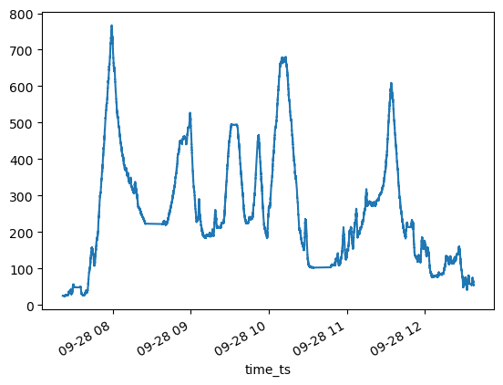

```python
combined_df['altitude'].plot()
```

```python
combined_df['altitude'].max()
```

```
767.1767950000005
```

```python
# 위경도 정보 역시 센서의 응답 속도에 따른 지연 계측이 존재
combined_df['Latitude'].min()
```

```
0.0
```

```python
# 위도 최대값 확인 -> 위경도의 지연 계측값만 imputation 실시
combined_df['Latitude'].max()
```

```
38.30394333
```

```python
combined_df['Latitude'] = combined_df['Latitude'].replace(0, method='bfill')
combined_df2['Latitude'] = combined_df2['Latitude'].replace(0, method='bfill')
```

```python
combined_df['Longitude'] = combined_df['Longitude'].replace(0, method='bfill')
combined_df2['Longitude'] = combined_df2['Longitude'].replace(0, method='bfill')
```

```python
print(combined_df['Latitude'].quantile([0, 1]))
print(combined_df['Longitude'].quantile([0, 1]))
print(combined_df2['Latitude'].quantile([0, 1]))
print(combined_df2['Longitude'].quantile([0, 1]))
```

```
0.0    37.726653
1.0    38.303943
Name: Latitude, dtype: float64
0.0    127.063683
1.0    128.555674
Name: Longitude, dtype: float64
0.0    37.726665
1.0    37.930565
Name: Latitude, dtype: float64
0.0    127.058369
1.0    127.785119
Name: Longitude, dtype: float64
```

## 2. 구간별 ANOVA 실시 (A~E 코스)

### ANOVA를 위한 그룹 데이터 분리

```python
combined_df.columns
```

```
Index(['gFx', 'gFy', 'gFz', 'ax', 'ay', 'az', 'wx', 'wy', 'wz', 'p', 'Bx',
       'By', 'Bz', 'I', 'Azimuth', 'Pitch', 'Roll', 'Latitude', 'Longitude',
       'Speed (m/s)', 'course', 'speed(km/h)', 'p_adj', 'altitude'],
      dtype='object')
```

```python
gFx_A = combined_df.loc[combined_df["course"] == "A", "gFx"]
gFx_B = combined_df.loc[combined_df["course"] == "B", "gFx"]
gFx_C = combined_df.loc[combined_df["course"] == "C", "gFx"]
gFx_D = combined_df.loc[combined_df["course"] == "D", "gFx"]
gFx_E = combined_df.loc[combined_df["course"] == "E", "gFx"]
```

```python
gFy_A = combined_df.loc[combined_df["course"] == "A", "gFy"]
gFy_B = combined_df.loc[combined_df["course"] == "B", "gFy"]
gFy_C = combined_df.loc[combined_df["course"] == "C", "gFy"]
gFy_D = combined_df.loc[combined_df["course"] == "D", "gFy"]
gFy_E = combined_df.loc[combined_df["course"] == "E", "gFy"]
```

```python
gFz_A = combined_df.loc[combined_df["course"] == "A", "gFz"]
gFz_B = combined_df.loc[combined_df["course"] == "B", "gFz"]
gFz_C = combined_df.loc[combined_df["course"] == "C", "gFz"]
gFz_D = combined_df.loc[combined_df["course"] == "D", "gFz"]
gFz_E = combined_df.loc[combined_df["course"] == "E", "gFz"]
```

```python
ax_A = combined_df.loc[combined_df["course"] == "A", "ax"]
ax_B = combined_df.loc[combined_df["course"] == "B", "ax"]
ax_C = combined_df.loc[combined_df["course"] == "C", "ax"]
ax_D = combined_df.loc[combined_df["course"] == "D", "ax"]
ax_E = combined_df.loc[combined_df["course"] == "E", "ax"]
```

```python
ay_A = combined_df.loc[combined_df["course"] == "A", "ay"]
ay_B = combined_df.loc[combined_df["course"] == "B", "ay"]
ay_C = combined_df.loc[combined_df["course"] == "C", "ay"]
ay_D = combined_df.loc[combined_df["course"] == "D", "ay"]
ay_E = combined_df.loc[combined_df["course"] == "E", "ay"]
```

```python
az_A = combined_df.loc[combined_df["course"] == "A", "az"]
az_B = combined_df.loc[combined_df["course"] == "B", "az"]
az_C = combined_df.loc[combined_df["course"] == "C", "az"]
az_D = combined_df.loc[combined_df["course"] == "D", "az"]
az_E = combined_df.loc[combined_df["course"] == "E", "az"]
```

```python
wx_A = combined_df.loc[combined_df["course"] == "A", "wx"]
wx_B = combined_df.loc[combined_df["course"] == "B", "wx"]
wx_C = combined_df.loc[combined_df["course"] == "C", "wx"]
wx_D = combined_df.loc[combined_df["course"] == "D", "wx"]
wx_E = combined_df.loc[combined_df["course"] == "E", "wx"]
```

```python
wy_A = combined_df.loc[combined_df["course"] == "A", "wy"]
wy_B = combined_df.loc[combined_df["course"] == "B", "wy"]
wy_C = combined_df.loc[combined_df["course"] == "C", "wy"]
wy_D = combined_df.loc[combined_df["course"] == "D", "wy"]
wy_E = combined_df.loc[combined_df["course"] == "E", "wy"]
```

```python
wz_A = combined_df.loc[combined_df["course"] == "A", "wz"]
wz_B = combined_df.loc[combined_df["course"] == "B", "wz"]
wz_C = combined_df.loc[combined_df["course"] == "C", "wz"]
wz_D = combined_df.loc[combined_df["course"] == "D", "wz"]
wz_E = combined_df.loc[combined_df["course"] == "E", "wz"]
```

```python
gFx_list = [gFx_A, gFx_B, gFx_C, gFx_D, gFx_E]
gFy_list = [gFy_A, gFy_B, gFy_C, gFy_D, gFy_E]
gFz_list = [gFz_A, gFz_B, gFz_C, gFz_D, gFz_E]

ax_list = [ax_A, ax_B, ax_C, ax_D, ax_E]
ay_list = [ay_A, ay_B, ay_C, ay_D, ay_E]
az_list = [az_A, az_B, az_C, az_D, az_E]

wx_list = [wx_A, wx_B, wx_C, wx_D, wx_E]
wy_list = [wy_A, wy_B, wy_C, wy_D, wy_E]
wz_list = [wz_A, wz_B, wz_C, wz_D, wz_E]

data_list = [gFx_list, gFy_list, gFz_list, ax_list, ay_list, az_list, wx_list, wy_list, wz_list]
```

### 5개 구간에 대한 ANOVA 실시

```python
import scipy.stats as stats
```

```python
## 정규성 검정 & 왜도 검사

for index, data_seq in enumerate(data_list):
    print('\n', "-"*50, '\n', f'test{index + 1}', '\n')
    for data in data_seq:
        print( stats.shapiro( data )
              , 'skewness test: {}'.format( abs(stats.skew(data , bias = False) ) )
              , sep = '\n'
             )
```

```
 --------------------------------------------------
 test1

ShapiroResult(statistic=0.9725920557975769, pvalue=0.0)
skewness test: 0.005639428239745883
ShapiroResult(statistic=0.9627367854118347, pvalue=0.0)
skewness test: 0.008872640643465962
ShapiroResult(statistic=0.98589688539505, pvalue=0.0)
skewness test: 0.02046510965184235
```

```
ShapiroResult(statistic=0.9758158922195435, pvalue=0.0)
skewness test: 0.018684220776954162
ShapiroResult(statistic=0.983237087726593, pvalue=0.0)
skewness test: 0.02085737828741636

 --------------------------------------------------
 test2

ShapiroResult(statistic=0.9107025861740112, pvalue=0.0)
skewness test: 0.2882152927303208
ShapiroResult(statistic=0.9533060789108276, pvalue=0.0)
skewness test: 0.3480149007694987
ShapiroResult(statistic=0.9748739004135132, pvalue=0.0)
skewness test: 0.26909331709218537
ShapiroResult(statistic=0.9410473108291626, pvalue=0.0)
skewness test: 0.26602043333530534
ShapiroResult(statistic=0.9593027234077454, pvalue=0.0)
skewness test: 0.16512808492804776

 --------------------------------------------------
 test3

ShapiroResult(statistic=0.9805821180343628, pvalue=0.0)
skewness test: 0.12876199880289374
ShapiroResult(statistic=0.9793277978897095, pvalue=0.0)
skewness test: 0.03083798852558234
ShapiroResult(statistic=0.9905204772949219, pvalue=0.0)
skewness test: 0.1929224780044024
ShapiroResult(statistic=0.9799076318740845, pvalue=0.0)
skewness test: 0.13492118827892183
ShapiroResult(statistic=0.9869078993797302, pvalue=0.0)
skewness test: 0.028727801386256153

 --------------------------------------------------
 test4

ShapiroResult(statistic=0.9601431488990784, pvalue=0.0)
skewness test: 0.04516801922500407
ShapiroResult(statistic=0.9458114504814148, pvalue=0.0)
skewness test: 0.025756663366975185
```

[output cut: 61 more lines]

```
skewness test: 0.024690471017935305

 --------------------------------------------------
 test9

ShapiroResult(statistic=0.9559361934661865, pvalue=0.0)
skewness test: 0.06959101598199728
ShapiroResult(statistic=0.9314869046211243, pvalue=0.0)
skewness test: 0.06108798220701196
ShapiroResult(statistic=0.9520021677017212, pvalue=0.0)
skewness test: 0.20359365395226225
ShapiroResult(statistic=0.9278424382209778, pvalue=0.0)
skewness test: 0.14090724347438824
ShapiroResult(statistic=0.9649237990379333, pvalue=0.0)
skewness test: 0.060836925577210356
```

```python
## 등분산성 검정
## Bartlett’s test tests the null hypothesis that all input samples are from populations with equal variances.
## So best case scenario is not to reject null hypothesis.
from scipy.stats import bartlett

for index, data_seq in enumerate(data_list):
    print('\n', "-"*50, '\n', f'test{index + 1}', '\n')
    print(stats.bartlett(data_seq[0], data_seq[1], data_seq[2], data_seq[3], data_seq[4]))
    print(stats.levene(data_seq[0], data_seq[1], data_seq[2], data_seq[3], data_seq[4]))
```

```
 --------------------------------------------------
 test1

BartlettResult(statistic=83590.92987607364, pvalue=0.0)
LeveneResult(statistic=15686.349467656748, pvalue=0.0)

 --------------------------------------------------
 test2

BartlettResult(statistic=521314.4921783509, pvalue=0.0)
LeveneResult(statistic=60402.435146368975, pvalue=0.0)

 --------------------------------------------------
 test3

BartlettResult(statistic=61136.092849226276, pvalue=0.0)
LeveneResult(statistic=11865.447629549797, pvalue=0.0)

 --------------------------------------------------
 test4

BartlettResult(statistic=116227.99081165565, pvalue=0.0)
LeveneResult(statistic=18050.20186935587, pvalue=0.0)

 --------------------------------------------------
 test5

BartlettResult(statistic=334962.87484584283, pvalue=0.0)
LeveneResult(statistic=38720.782406588194, pvalue=0.0)

 --------------------------------------------------
 test6

BartlettResult(statistic=113563.38132775943, pvalue=0.0)
LeveneResult(statistic=19173.51502982685, pvalue=0.0)

 --------------------------------------------------
 test7

BartlettResult(statistic=346309.20382373175, pvalue=0.0)
LeveneResult(statistic=38206.71575268044, pvalue=0.0)

 --------------------------------------------------
 test8

BartlettResult(statistic=129559.16349138942, pvalue=0.0)
LeveneResult(statistic=19972.842359806316, pvalue=0.0)

 --------------------------------------------------
 test9

BartlettResult(statistic=112579.4085630633, pvalue=0.0)
LeveneResult(statistic=14904.221611239058, pvalue=0.0)
```

```python
for index, data_seq in enumerate(data_list):
    print('\n', "-"*100, '\n', f'test{index + 1}', '\n')

    # ANOVA 수행
    statistic, p_value = stats.f_oneway(data_seq[0], data_seq[1], data_seq[2], data_seq[3], data_seq[4])

    # 결과 출력
    print("ANOVA Statistic:", statistic)
    print("p-value:", p_value)

    # p-value를 기준으로 유의수준을 설정하고 결과를 해석
    alpha = 0.05
    if p_value < alpha:
        print("p-value가 유의수준 {} 보다 작으므로 그룹 간에 통계적으로 유의한 차이가 있습니다.".format(alpha))
    else:
        print("p-value가 유의수준 {} 이상이므로 그룹 간에 통계적으로 유의한 차이가 없습니다.".format(alpha))
```

```
 ----------------------------------------------------------------------------------------------------
 test1

ANOVA Statistic: 7.829373231982656
p-value: 2.6373789215601044e-06
p-value가 유의수준 0.05 보다 작으므로 그룹 간에 통계적으로 유의한 차이가 있습니다.

 ----------------------------------------------------------------------------------------------------
 test2

ANOVA Statistic: 1060.155793888516
p-value: 0.0
p-value가 유의수준 0.05 보다 작으므로 그룹 간에 통계적으로 유의한 차이가 있습니다.

 ----------------------------------------------------------------------------------------------------
 test3

ANOVA Statistic: 372.34610521702047
p-value: 3.57e-321
p-value가 유의수준 0.05 보다 작으므로 그룹 간에 통계적으로 유의한 차이가 있습니다.

 ----------------------------------------------------------------------------------------------------
 test4

ANOVA Statistic: 3.627965760990316
p-value: 0.0058285694708574065
p-value가 유의수준 0.05 보다 작으므로 그룹 간에 통계적으로 유의한 차이가 있습니다.

 ----------------------------------------------------------------------------------------------------
 test5

ANOVA Statistic: 12.97619263124391
p-value: 1.4445333156098753e-10
p-value가 유의수준 0.05 보다 작으므로 그룹 간에 통계적으로 유의한 차이가 있습니다.

 ----------------------------------------------------------------------------------------------------
 test6

ANOVA Statistic: 5663.196374733193
p-value: 0.0
p-value가 유의수준 0.05 보다 작으므로 그룹 간에 통계적으로 유의한 차이가 있습니다.

 ----------------------------------------------------------------------------------------------------
 test7

ANOVA Statistic: 10.167474186321519
p-value: 3.146303963866126e-08
p-value가 유의수준 0.05 보다 작으므로 그룹 간에 통계적으로 유의한 차이가 있습니다.

 ----------------------------------------------------------------------------------------------------
 test8

ANOVA Statistic: 45.592903669418064
p-value: 2.3151590676870052e-38
p-value가 유의수준 0.05 보다 작으므로 그룹 간에 통계적으로 유의한 차이가 있습니다.

 ----------------------------------------------------------------------------------------------------
 test9

ANOVA Statistic: 21.335893194140326
p-value: 1.2834552116041028e-17
p-value가 유의수준 0.05 보다 작으므로 그룹 간에 통계적으로 유의한 차이가 있습니다.
```

어차피 n수가 너무 많다보니 p 값이 작게 나올 수 밖에 없는 데이터의 한계가 있어 보임

```python
# 다른 방식으로 출력해 보기

for index, data_seq in enumerate(data_list):
    print('\n', "-"*100, '\n', f'test{index + 1}', '\n')

    # ANOVA 수행
    F, p = stats.f_oneway(data_seq[0], data_seq[1], data_seq[2], data_seq[3], data_seq[4])
    print( 'F-Ratio: {}'.format(F) , 'p-value:{}'.format(p), sep = '\n')
```

```
 ----------------------------------------------------------------------------------------------------
 test1

F-Ratio: 7.829373231982656
p-value:2.6373789215601044e-06

 ----------------------------------------------------------------------------------------------------
 test2

F-Ratio: 1060.155793888516
p-value:0.0

 ----------------------------------------------------------------------------------------------------
 test3

F-Ratio: 372.34610521702047
p-value:3.57e-321

 ----------------------------------------------------------------------------------------------------
 test4

F-Ratio: 3.627965760990316
p-value:0.0058285694708574065

 ----------------------------------------------------------------------------------------------------
 test5

F-Ratio: 12.97619263124391
p-value:1.4445333156098753e-10

 ----------------------------------------------------------------------------------------------------
 test6

F-Ratio: 5663.196374733193
p-value:0.0

 ----------------------------------------------------------------------------------------------------
 test7

F-Ratio: 10.167474186321519
p-value:3.146303963866126e-08

 ----------------------------------------------------------------------------------------------------
 test8

F-Ratio: 45.592903669418064
p-value:2.3151590676870052e-38

 ----------------------------------------------------------------------------------------------------
 test9

F-Ratio: 21.335893194140326
p-value:1.2834552116041028e-17
```

```python
combined_df["course"]
```

```
time_ts
2023-09-28 07:21:27.939    A
2023-09-28 07:21:27.975    A
2023-09-28 07:21:27.985    A
2023-09-28 07:21:28.003    A
2023-09-28 07:21:28.005    A
                          ..
2023-09-28 12:37:39.319    E
2023-09-28 12:37:39.320    E
2023-09-28 12:37:39.322    E
2023-09-28 12:37:39.323    E
2023-09-28 12:37:39.324    E
Name: course, Length: 2505868, dtype: object
```

```python
 ## Stats Model을 활용한 방법2.
from statsmodels.formula.api import ols
from statsmodels.stats.anova import anova_lm

model = ols('gFx ~ C(course)', combined_df).fit()
anova_lm(model)
```

|  | df | sum_sq | mean_sq | F | PR(>F) |
| --- | --- | --- | --- | --- | --- |
| C(course) | 4.0 | 0.787246 | 0.196811 | 7.829373 | 0.000003 |
| Residual | 2505863.0 | 62991.309837 | 0.025138 | NaN | NaN |

```python
model = ols('gFy ~ C(course)', combined_df).fit()
anova_lm(model)
model.summary()
```

OLS Regression Results

| Dep. Variable: | gFy | R-squared: | 0.002 |
| --- | --- | --- | --- |
| Model: | OLS | Adj. R-squared: | 0.002 |
| Method: | Least Squares | F-statistic: | 1060. |
| Date: | Wed, 04 Oct 2023 | Prob (F-statistic): | 0.00 |
| Time: | 00:19:53 | Log-Likelihood: | 1.4390e+06 |
| No. Observations: | 2505868 | AIC: | -2.878e+06 |
| Df Residuals: | 2505863 | BIC: | -2.878e+06 |
| Df Model: | 4 |  |  |
| Covariance Type: | nonrobust |  |  |

|  | coef | std err | t | P>\|t\| | [0.025 | 0.975] |
| --- | --- | --- | --- | --- | --- | --- |
| Intercept | -0.0115 | 0.000 | -62.669 | 0.000 | -0.012 | -0.011 |
| C(course)[T.B] | -0.0151 | 0.000 | -58.460 | 0.000 | -0.016 | -0.015 |
| C(course)[T.C] | -0.0117 | 0.000 | -42.744 | 0.000 | -0.012 | -0.011 |
| C(course)[T.D] | -0.0136 | 0.000 | -51.721 | 0.000 | -0.014 | -0.013 |
| C(course)[T.E] | -0.0113 | 0.000 | -40.848 | 0.000 | -0.012 | -0.011 |

| Omnibus: | 248823.105 | Durbin-Watson: | 0.060 |
| --- | --- | --- | --- |
| Prob(Omnibus): | 0.000 | Jarque-Bera (JB): | 1383820.937 |
| Skew: | -0.321 | Prob(JB): | 0.00 |
| Kurtosis: | 6.584 | Cond. No. | 5.59 |

Notes:  
[1] Standard Errors assume that the covariance matrix of the errors is correctly specified.

### 구간별 가속도 변화 분포에 대한 시각화 (gFx ~ az 변수별)

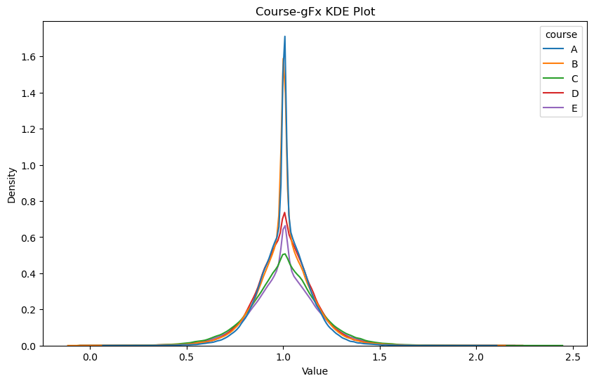

```python
# Kernel Density Estimate Plot gFx
import matplotlib.pyplot as plt
import seaborn as sns
plt.rcParams['figure.figsize'] = [10, 6]

sns.kdeplot(data=combined_df, x='gFx', hue='course', legend=True)
plt.title('Course-gFx KDE Plot')
plt.xlabel('Value')
plt.ylabel('Density')
```

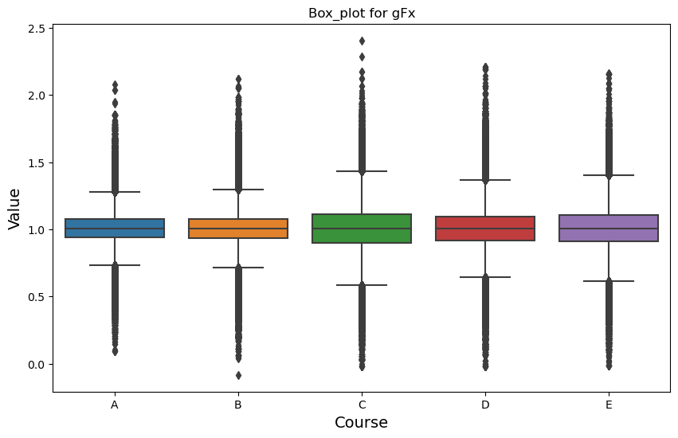

```python
# Boxplot gFx
sns.boxplot(x='course', y='gFx', data=combined_df)
plt.xlabel("Course", fontsize=14)
plt.ylabel("Value", fontsize=14)
plt.title("Box_plot for gFx")
plt.show()
```

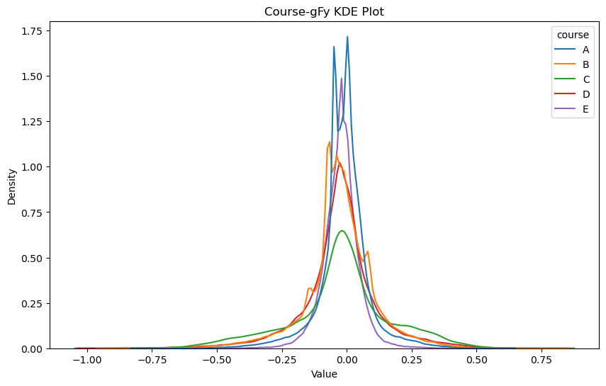

```python
# Kernel Density Estimate Plot gFy
import matplotlib.pyplot as plt
import seaborn as sns
plt.rcParams['figure.figsize'] = [10, 6]

sns.kdeplot(data=combined_df, x='gFy', hue='course', legend=True)
plt.title('Course-gFy KDE Plot')
plt.xlabel('Value')
plt.ylabel('Density')
```

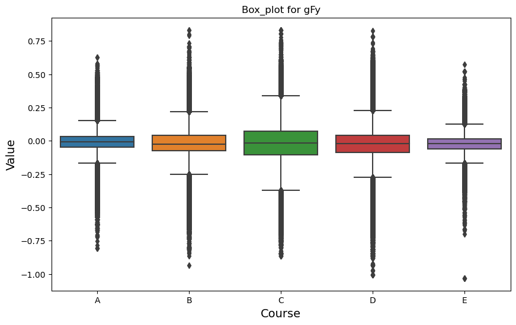

```python
# Boxplot gFy
sns.boxplot(x='course', y='gFy', data=combined_df)
plt.xlabel("Course", fontsize=14)
plt.ylabel("Value", fontsize=14)
plt.title("Box_plot for gFy")
plt.show()
```

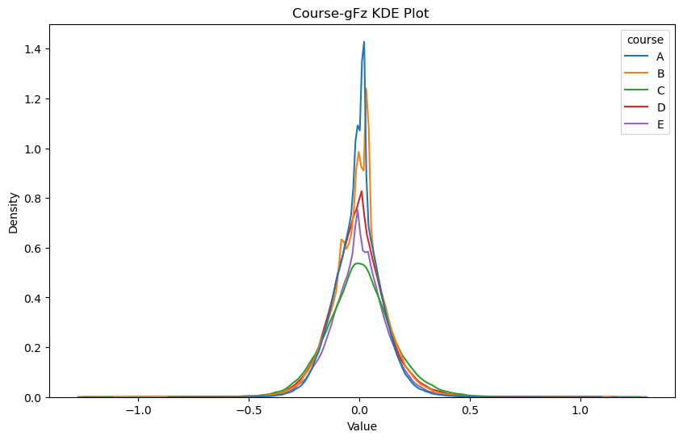

```python
# Kernel Density Estimate Plot gFz
import matplotlib.pyplot as plt
import seaborn as sns
plt.rcParams['figure.figsize'] = [10, 6]

sns.kdeplot(data=combined_df, x='gFz', hue='course', legend=True)
plt.title('Course-gFz KDE Plot ')
plt.xlabel('Value')
plt.ylabel('Density')
```

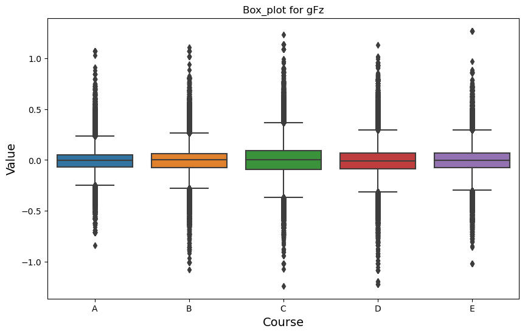

```python
# Boxplot gFz
sns.boxplot(x='course', y='gFz', data=combined_df)
plt.xlabel("Course", fontsize=14)
plt.ylabel("Value", fontsize=14)
plt.title("Box_plot for gFz")
plt.show()
```

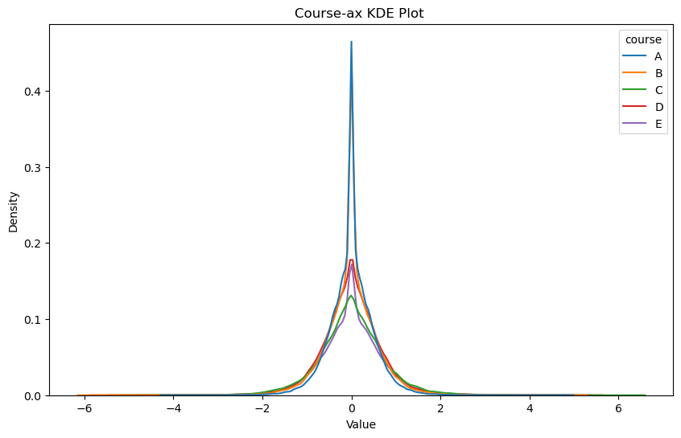

```python
# Kernel Density Estimate Plot ax
import matplotlib.pyplot as plt
import seaborn as sns
plt.rcParams['figure.figsize'] = [10, 6]

sns.kdeplot(data=combined_df, x='ax', hue='course', legend=True)
plt.title('Course-ax KDE Plot ')
plt.xlabel('Value')
plt.ylabel('Density')
```

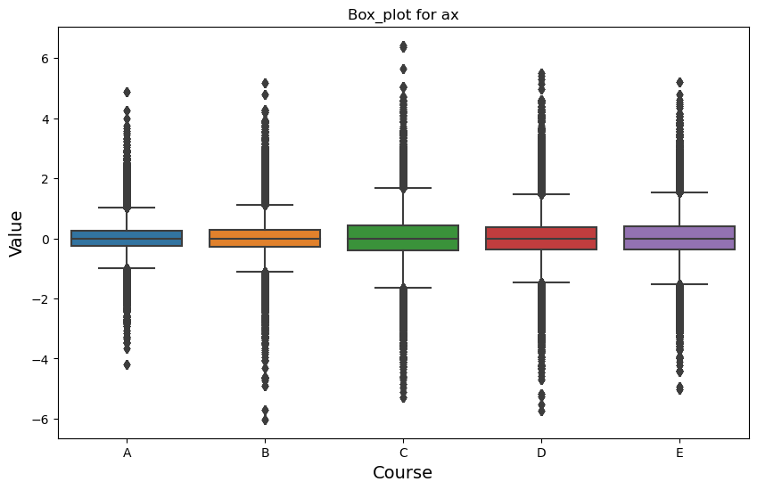

```python
# Boxplot ax
sns.boxplot(x='course', y='ax', data=combined_df)
plt.xlabel("Course", fontsize=14)
plt.ylabel("Value", fontsize=14)
plt.title("Box_plot for ax")
plt.show()
```

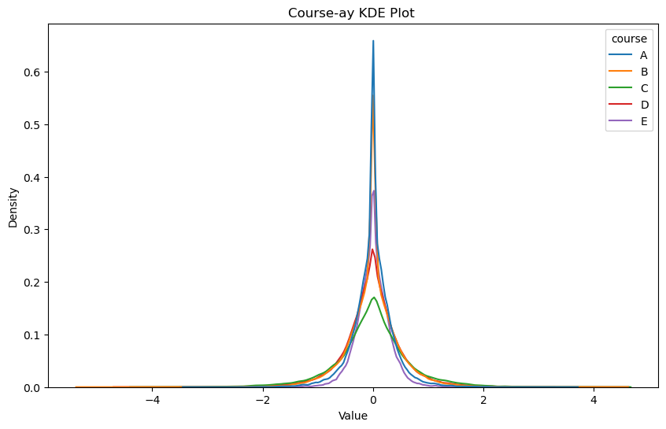

```python
# Kernel Density Estimate Plot ay
import matplotlib.pyplot as plt
import seaborn as sns
plt.rcParams['figure.figsize'] = [10, 6]

sns.kdeplot(data=combined_df, x='ay', hue='course', legend=True)
plt.title('Course-ay KDE Plot ')
plt.xlabel('Value')
plt.ylabel('Density')
```

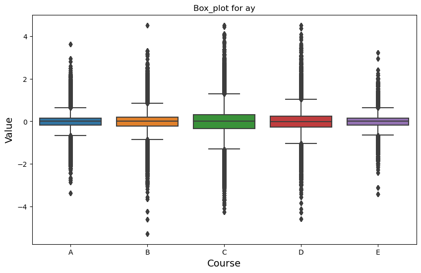

```python
# Boxplot ay
sns.boxplot(x='course', y='ay', data=combined_df)
plt.xlabel("Course", fontsize=14)
plt.ylabel("Value", fontsize=14)
plt.title("Box_plot for ay")
plt.show()
```

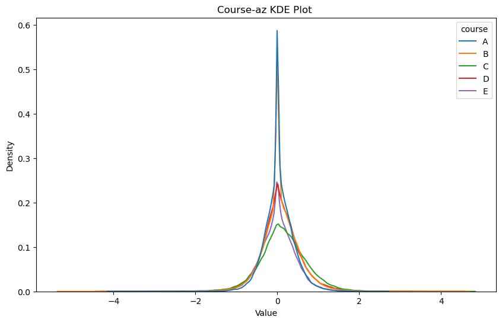

```python
# Kernel Density Estimate Plot az
import matplotlib.pyplot as plt
import seaborn as sns
plt.rcParams['figure.figsize'] = [10, 6]

sns.kdeplot(data=combined_df, x='az', hue='course', legend=True)
plt.title('Course-az KDE Plot ')
plt.xlabel('Value')
plt.ylabel('Density')
```

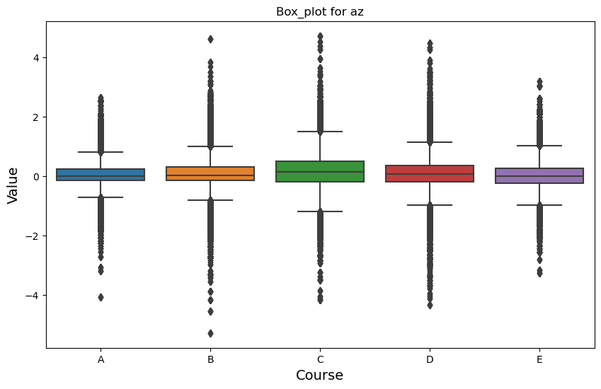

```python
# Boxplot az
sns.boxplot(x='course', y='az', data=combined_df)
plt.xlabel("Course", fontsize=14)
plt.ylabel("Value", fontsize=14)
plt.title("Box_plot for az")
plt.show()
```

## 3. 지리적 시각화(geovisualization)

전체 데이터를 약 1/25로 축소하여 folium 패키지를 이용한 시각화 실시

```python
# 1. combined_df의 초당 평균 수집건수 확인
# 초당로 주기로 리샘플링하고 각 구간 내의 평균 row 수 계산
seconds_per_row = combined_df.resample('S').count().mean()
print(f"combined_df의 초당 평균 row 수: {seconds_per_row[0]}")
```

```
combined_df의 초당 평균 row 수: 132.07547567596058
```

```python
# 2. 데이터 축소를 위한 계통 추출 실시
import random

# 시드를 설정
random.seed(928)  # 원하는 시드 값을 지정합니다.

# systematic sampling을 위한 파라미터 설정
sample_size = 100000  # 표본 크기
sampling_interval = 25  # 간격 설정 (예: 5)

# 시작점 랜덤 설정
start_point = random.randint(0, sampling_interval - 1)

# systematic sampling을 적용하여 표본 추출
sampled_data = combined_df[start_point::sampling_interval].head(sample_size)

print(combined_df.iloc[0:20, 0:6])
print(sampled_data.iloc[0:20, 0:6])
```

```
                            gFx     gFy     gFz   ax   ay   az
time_ts
2023-09-28 07:21:27.939  1.0041 -0.0458  0.0225  0.0  0.0  0.0
2023-09-28 07:21:27.975  1.0041 -0.0458  0.0225  0.0  0.0  0.0
2023-09-28 07:21:27.985  1.0041 -0.0458  0.0225  0.0  0.0  0.0
2023-09-28 07:21:28.003  0.9924 -0.0002 -0.0425  0.0  0.0  0.0
2023-09-28 07:21:28.005  0.9995  0.0190 -0.0742  0.0  0.0  0.0
2023-09-28 07:21:28.006  0.9898 -0.0038 -0.0446  0.0  0.0  0.0
2023-09-28 07:21:28.007  1.0102 -0.0380  0.0233  0.0  0.0  0.0
2023-09-28 07:21:28.041  1.0102 -0.0380  0.0233  0.0  0.0  0.0
2023-09-28 07:21:28.045  1.0102 -0.0380  0.0233  0.0  0.0  0.0
2023-09-28 07:21:28.047  1.0102 -0.0380  0.0233  0.0  0.0  0.0
2023-09-28 07:21:28.050  1.0102 -0.0380  0.0233  0.0  0.0  0.0
2023-09-28 07:21:28.070  1.0349 -0.0682  0.0228  0.0  0.0  0.0
2023-09-28 07:21:28.071  1.0150 -0.0400  0.0162  0.0  0.0  0.0
2023-09-28 07:21:28.072  0.9812 -0.0122 -0.0326  0.0  0.0  0.0
2023-09-28 07:21:28.075  0.9812 -0.0122 -0.0326  0.0  0.0  0.0
2023-09-28 07:21:28.080  1.0012  0.0131 -0.0435  0.0  0.0  0.0
2023-09-28 07:21:28.086  1.0012  0.0131 -0.0435  0.0  0.0  0.0
2023-09-28 07:21:28.087  1.0012  0.0131 -0.0435  0.0  0.0  0.0
2023-09-28 07:21:28.105  1.0012  0.0131 -0.0435  0.0  0.0  0.0
2023-09-28 07:21:28.107  1.0012  0.0131 -0.0435  0.0  0.0  0.0
                            gFx     gFy     gFz      ax      ay      az
time_ts
2023-09-28 07:21:28.047  1.0102 -0.0380  0.0233  0.0000  0.0000  0.0000
2023-09-28 07:21:28.212  1.0102 -0.0140 -0.0315  0.0121  0.0502 -0.0561
2023-09-28 07:21:28.407  1.0184 -0.0358 -0.0217  0.0125  0.0278 -0.0779
2023-09-28 07:21:28.572  1.0045 -0.0145 -0.0049 -0.0041  0.0303  0.0123
2023-09-28 07:21:28.753  0.9991 -0.0283 -0.0067 -0.0231 -0.0044 -0.0048
2023-09-28 07:21:28.945  0.9879 -0.0178 -0.0151  0.0631 -0.0370  0.0844
2023-09-28 07:21:29.106  1.0151 -0.0183 -0.0090 -0.0612  0.0017 -0.0081
2023-09-28 07:21:29.273  1.0235 -0.0330 -0.0210  0.0429 -0.0097  0.0327
2023-09-28 07:21:29.438  1.0189 -0.0210 -0.0070 -0.0370 -0.0032  0.0377
2023-09-28 07:21:29.626  0.9986 -0.0272 -0.0085 -0.0185 -0.0025  0.0230
2023-09-28 07:21:29.785  1.0209 -0.0198 -0.0006  0.0099 -0.0073  0.0500
2023-09-28 07:21:29.970  1.0259 -0.0266 -0.0035 -0.0013 -0.0130 -0.0020
2023-09-28 07:21:30.147  0.9950 -0.0305 -0.0154 -0.0381  0.0087  0.0673
2023-09-28 07:21:30.308  1.0022 -0.0227 -0.0171  0.0021  0.0002  0.0107
2023-09-28 07:21:30.475  1.0180 -0.0204  0.0015  0.0040 -0.0147  0.0389
2023-09-28 07:21:30.679  1.0096 -0.0187 -0.0017  0.0255 -0.0147  0.0296
2023-09-28 07:21:30.830  1.0069 -0.0222 -0.0242 -0.0415 -0.0035  0.0341
2023-09-28 07:21:31.016  1.0108 -0.0264 -0.0166 -0.0167  0.0097  0.0276
2023-09-28 07:21:31.212  0.9984 -0.0171 -0.0007 -0.0141  0.0060  0.0336
2023-09-28 07:21:31.364  1.0080 -0.0275 -0.0177 -0.0015  0.0120 -0.0067
```

```python
# 3. 초당 평균 수집 건수 확인
#    'S' 초 주기로 리샘플링하고 각 구간 내의 평균 row 수 계산
sampled_data_nrs = sampled_data.resample('S').count().mean()
print(f"초당 평균 row 수: {sampled_data_nrs[0]}")
```

```
초당 평균 row 수: 5.282341133590407
```

### 1일차 경로 그리기

```python
# 1일차 경로 출력

import folium
import pandas as pd

# Folium 지도 객체 생성
m = folium.Map(location=[sampled_data['Latitude'].mean(), sampled_data['Longitude'].mean()], zoom_start=10)

# course 값에 따라 다른 색상 부여
color_dict = {'A': '#4C749F', 'B': '#CC8133', 'C': '#5E9241', 'D' : '#A83D3E', 'E' : '#8B72B0'}

# 데이터프레임 순회하면서 지도에 PolyLine으로 경로 표시
for course, group in sampled_data.groupby('course'):
    locations = list(zip(group['Latitude'], group['Longitude']))
    folium.PolyLine(locations=locations, color=color_dict[course], weight=10, opacity=1, popup=f'Course: {course}').add_to(m)

# 지도를 HTML 파일로 저장
m.save('1st_day_course.html')  # HTML 파일로 저장
```

### 2일차 경로 그리기

```python
# 2일차 경로 출력

import folium
import pandas as pd

# Folium 지도 객체 생성
m = folium.Map(location=[combined_df2['Latitude'].mean(), combined_df2['Longitude'].mean()], zoom_start=10)

# course 값에 따라 다른 색상 부여
color_dict = {'F': '#4C749F', 'G' : '#CC8133', 'H' : '#5E9241'}

# 데이터프레임 순회하면서 지도에 PolyLine으로 경로 표시
for course, group in combined_df2.groupby('course'):

    # 코스가 "F"인 경우 opacity를 1로, 그렇지 않은 경우 0.5로 설정 (갈 때와 올 때 경로가 동일하므로 약간의 차이를 주고자 함)
    opacity_value = 1 if course == "F" else 0.7
    locations = list(zip(group['Latitude'], group['Longitude']))
    folium.PolyLine(locations=locations, color=color_dict[course], weight=10, opacity=opacity_value, popup=f'Course: {course}').add_to(m)

# 지도를 HTML 파일로 저장
m.save('2nd_day_course.html')  # HTML 파일로 저장
```

### (강원도 횡단) gFx

```python
import folium

lats = sampled_data['Latitude']
lons = sampled_data['Longitude']
colors = sampled_data['gFx']

m = folium.Map(location=[sampled_data['Latitude'].mean(), sampled_data['Longitude'].mean()], zoom_start=10)

color_line = folium.ColorLine(
    positions=list(zip(lats, lons)),
    colors=colors,
    colormap=["red", "orange", "yellow", "green", "blue", "purple", "blue", "green", "yellow", "orange", "red"],
    weight=10,
).add_to(m)

m.save('colorline_for_gFx.html')
```

### (강원도 횡단) gFy

```python
import folium

lats = sampled_data['Latitude']
lons = sampled_data['Longitude']
colors = sampled_data['gFy']

m = folium.Map(location=[sampled_data['Latitude'].mean(), sampled_data['Longitude'].mean()], zoom_start=10)

color_line = folium.ColorLine(
    positions=list(zip(lats, lons)),
    colors=colors,
    colormap=["red", "orange", "yellow", "green", "blue", "purple", "blue", "green", "yellow", "orange", "red"],
    weight=10,
).add_to(m)

m.save('colorline_for_gFy.html')
```

### (강원도 횡단) gFz

```python
import folium

lats = sampled_data['Latitude']
lons = sampled_data['Longitude']
colors = sampled_data['gFz']

m = folium.Map(location=[sampled_data['Latitude'].mean(), sampled_data['Longitude'].mean()], zoom_start=10)

color_line = folium.ColorLine(
    positions=list(zip(lats, lons)),
    colors=colors,
    colormap=["red", "orange", "yellow", "green", "blue", "purple", "blue", "green", "yellow", "orange", "red"],
    weight=10,
).add_to(m)

m.save('colorline_for_gFz.html')
```

### (강원도 횡단) ax

```python
import folium

lats = sampled_data['Latitude']
lons = sampled_data['Longitude']
colors = sampled_data['ax']

m = folium.Map(location=[sampled_data['Latitude'].mean(), sampled_data['Longitude'].mean()], zoom_start=10)

color_line = folium.ColorLine(
    positions=list(zip(lats, lons)),
    colors=colors,
    colormap=["red", "orange", "yellow", "green", "blue", "purple", "blue", "green", "yellow", "orange", "red"],
    weight=10,
).add_to(m)

m.save('colorline_for_ax.html')
```

### (강원도 횡단) ay

```python
import folium

lats = sampled_data['Latitude']
lons = sampled_data['Longitude']
colors = sampled_data['ay']

m = folium.Map(location=[sampled_data['Latitude'].mean(), sampled_data['Longitude'].mean()], zoom_start=10)

color_line = folium.ColorLine(
    positions=list(zip(lats, lons)),
    colors=colors,
    colormap=["red", "orange", "yellow", "green", "blue", "purple", "blue", "green", "yellow", "orange", "red"],
    weight=10,
).add_to(m)

m.save('colorline_for_ay.html')
```

### (강원도 횡단) az

```python
import folium

lats = sampled_data['Latitude']
lons = sampled_data['Longitude']
colors = sampled_data['az']

m = folium.Map(location=[sampled_data['Latitude'].mean(), sampled_data['Longitude'].mean()], zoom_start=10)

color_line = folium.ColorLine(
    positions=list(zip(lats, lons)),
    colors=colors,
    colormap=["red", "orange", "yellow", "green", "blue", "purple", "blue", "green", "yellow", "orange", "red"],
    weight=10,
).add_to(m)

m.save('colorline_for_az.html')
```

### (강원도 횡단) wx

```python
import folium

lats = sampled_data['Latitude']
lons = sampled_data['Longitude']
colors = sampled_data['wx']

m = folium.Map(location=[sampled_data['Latitude'].mean(), sampled_data['Longitude'].mean()], zoom_start=10)

color_line = folium.ColorLine(
    positions=list(zip(lats, lons)),
    colors=colors,
    colormap=["red", "orange", "yellow", "green", "blue", "purple", "blue", "green", "yellow", "orange", "red"],
    weight=10,
).add_to(m)

m.save('colorline_for_wx.html')
```

### (강원도 횡단) wy

```python
import folium

lats = sampled_data['Latitude']
lons = sampled_data['Longitude']
colors = sampled_data['wy']

m = folium.Map(location=[sampled_data['Latitude'].mean(), sampled_data['Longitude'].mean()], zoom_start=10)

color_line = folium.ColorLine(
    positions=list(zip(lats, lons)),
    colors=colors,
    colormap=["red", "orange", "yellow", "green", "blue", "purple", "blue", "green", "yellow", "orange", "red"],
    weight=10,
).add_to(m)

m.save('colorline_for_wy.html')
```

### (강원도 횡단) wz

```python
import folium

lats = sampled_data['Latitude']
lons = sampled_data['Longitude']
colors = sampled_data['wz']

m = folium.Map(location=[sampled_data['Latitude'].mean(), sampled_data['Longitude'].mean()], zoom_start=10)

color_line = folium.ColorLine(
    positions=list(zip(lats, lons)),
    colors=colors,
    colormap=["red", "orange", "yellow", "green", "blue", "purple", "blue", "green", "yellow", "orange", "red"],
    weight=10,
).add_to(m)

m.save('colorline_for_wz.html')
```

### (강원도 횡단) Bx

```python
import folium

lats = sampled_data['Latitude']
lons = sampled_data['Longitude']
colors = sampled_data['Bx']

m = folium.Map(location=[sampled_data['Latitude'].mean(), sampled_data['Longitude'].mean()], zoom_start=10)

color_line = folium.ColorLine(
    positions=list(zip(lats, lons)),
    colors=colors,
    colormap=["red", "orange", "yellow", "green", "blue", "purple", "blue", "green", "yellow", "orange", "red"],
    weight=10,
).add_to(m)

m.save('colorline_for_Bx.html')
```

### (강원도 횡단) By

```python
import folium

lats = sampled_data['Latitude']
lons = sampled_data['Longitude']
colors = sampled_data['By']

m = folium.Map(location=[sampled_data['Latitude'].mean(), sampled_data['Longitude'].mean()], zoom_start=10)

color_line = folium.ColorLine(
    positions=list(zip(lats, lons)),
    colors=colors,
    colormap=["red", "orange", "yellow", "green", "blue", "purple", "blue", "green", "yellow", "orange", "red"],
    weight=10,
).add_to(m)

m.save('colorline_for_By.html')
```

### (강원도 횡단) Bz

```python
import folium

lats = sampled_data['Latitude']
lons = sampled_data['Longitude']
colors = sampled_data['Bz']

m = folium.Map(location=[sampled_data['Latitude'].mean(), sampled_data['Longitude'].mean()], zoom_start=10)

color_line = folium.ColorLine(
    positions=list(zip(lats, lons)),
    colors=colors,
    colormap=["red", "orange", "yellow", "green", "blue", "purple", "blue", "green", "yellow", "orange", "red"],
    weight=10,
).add_to(m)

m.save('colorline_for_Bz.html')
```

### (강원도 횡단) I

```python
import folium

lats = sampled_data['Latitude']
lons = sampled_data['Longitude']
colors = sampled_data['I']

m = folium.Map(location=[sampled_data['Latitude'].mean(), sampled_data['Longitude'].mean()], zoom_start=10)

color_line = folium.ColorLine(
    positions=list(zip(lats, lons)),
    colors=colors,
    colormap=["silver", "khaki", "beige", "yellow", "orange", "red"],
    weight=10,
).add_to(m)

m.save('colorline_for_I.html')
```

### (강원도 횡단) Azimuth

```python
import folium

lats = sampled_data['Latitude']
lons = sampled_data['Longitude']
colors = sampled_data['Azimuth']

m = folium.Map(location=[sampled_data['Latitude'].mean(), sampled_data['Longitude'].mean()], zoom_start=10)

color_line = folium.ColorLine(
    positions=list(zip(lats, lons)),
    colors=colors,
    colormap=["red", "orange", "yellow", "green", "blue", "purple", "blue", "green", "yellow", "orange", "red"],
    weight=10,
).add_to(m)

m.save('colorline_for_Azimuth.html')
```

### (강원도 횡단) Pitch

```python
import folium

lats = sampled_data['Latitude']
lons = sampled_data['Longitude']
colors = sampled_data['Pitch']

m = folium.Map(location=[sampled_data['Latitude'].mean(), sampled_data['Longitude'].mean()], zoom_start=10)

color_line = folium.ColorLine(
    positions=list(zip(lats, lons)),
    colors=colors,
    colormap=["purple", "blue", "green", "khaki","yellow", "orange", "red"],
    weight=10,
).add_to(m)

m.save('colorline_for_Pitch.html')
```

### (강원도 횡단) Roll

```python
import folium

lats = sampled_data['Latitude']
lons = sampled_data['Longitude']
colors = sampled_data['Roll']

m = folium.Map(location=[sampled_data['Latitude'].mean(), sampled_data['Longitude'].mean()], zoom_start=10)

color_line = folium.ColorLine(
    positions=list(zip(lats, lons)),
    colors=colors,
    colormap=["red", "orange", "yellow", "green", "blue", "purple", "blue", "green", "yellow", "orange", "red"],
    weight=10,
).add_to(m)

m.save('colorline_for_Roll.html')
```

### (강원도 횡단) speed(km/h)

```python
import folium

lats = sampled_data['Latitude']
lons = sampled_data['Longitude']
colors = sampled_data['speed(km/h)']

m = folium.Map(location=[sampled_data['Latitude'].mean(), sampled_data['Longitude'].mean()], zoom_start=10)

color_line = folium.ColorLine(
    positions=list(zip(lats, lons)),
    colors=colors,
    colormap=["darkslategray","darkgreen", "green", "forestgreen", "khaki", "gold", "orange", "red"],
    weight=10,
).add_to(m)

m.save('colorline_for_speed.html')
```

### (강원도 횡단) altitude

```python
import folium

lats = sampled_data['Latitude']
lons = sampled_data['Longitude']
colors = sampled_data['altitude']

m = folium.Map(location=[sampled_data['Latitude'].mean(), sampled_data['Longitude'].mean()], zoom_start=10)

color_line = folium.ColorLine(
    positions=list(zip(lats, lons)),
    colors=colors,
    colormap=["beige","gold", "green", "darkgreen"],
    weight=10,
).add_to(m)

m.save('colorline_for_altitude.html')
```

## 4. 향후 수행 방안

- **(Derived variable)** net force나 net gravity 등을 산출해 보기
- **(Outlier)** pyOD 패키지 이용, 각 방법론 별로 outlier를 detecting 해보기 (변수별, 관측 시간대별 수행 + I(lx)의 아웃라이어 활용 방법도 모색해보면서)
- **(Imputation)** 2일차 G구간과 H구간 사이의 결측 데이터를 imputation 하고 위도와 경도의 경우 정답값을 가지고 있는 F구간과 비교해 보기
  - 전통적인 방법과 pypots 패키지 구현 방법론 간 비교도 해보기
- **(Compression)** 센서 데이터를 압축하는 방법을 수행해보기(최적의 압축률은? 어떻게 평가하고 정할 수 있는지?)
- **(Augmentation)** 압축된 센서 데이터를 다시 복원하는 방법 수행해보기(복원률은? 정확도는? 어떻게 평가하고 정할 수 있는지?)